# R-Workshop

Simon Roth

31.03.2017

# Introduction

## Why R? Popularity

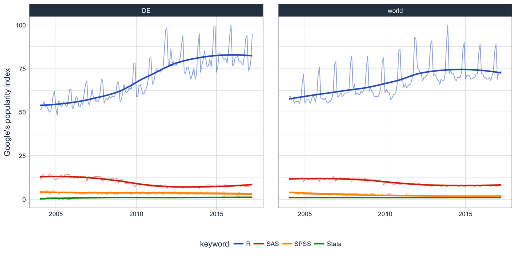

Note: Numbers represent search interest relative to the highest point on the chart for the given region and time. A value of 100 is the peak popularity for the term. A value of 50 means that the term is half as popular. Likewise a score of 0 means the term was less than 1% as popular as the peak [Google Trends](https://trends.google.com/trends/).

## Internationally seen…

[interactive chart not shown]

## Why R? Costs!

Statistical Package

Base

Standard

Pro

Professional

Source

$1210/y * LM

$2690/y * GLM * Logistic

$5400/y * Regularization * PCA

$8050/y * Time Series * Machine Learning

[IBM](https://www.ibm.com/us-en/marketplace/spss-statistics/purchase#product-header)

$8000/y

[Quora](https://www.quora.com/How-much-does-SAS-cost)

$595/y $1195

$845/y $1695

$6,445 Server Version

[Stata](http://www.stata.com/order/new/bus/single-user-licenses/)

free

free

free[^1]

free

[RStudio](https://www.rstudio.com/pricing/)

## Why R? Vitial Community

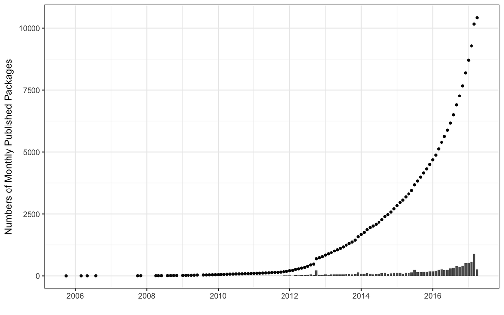

## Work Directory (Ordnerpfad)

```r
data_path <- "/Users/simonroth/Dropbox/methods/git/r_workshops/scripts/data/"
setwd(data_path) # warning!
getwd()
dir()
```

## themes avaible

- default
- simple
- sky
- beige
- serif
- solarized
- blood
- moon
- night
- black
- league (dark)
- white

## code highlighting

- tango
- pygments
- kate
- monochrome
- espresso
- zenburn
- haddock

## multicol?

1. item 1
2. item 2
- Eat eggs
- Drink coffee

## transition mods

Slide transition style:

- default
- fade
- slide
- convex
- concave
- zoom
- none

# Transitions

## latex

LaTeX math $\sum_{i=1}^n \alpha_i$ = $\sum_{i=1}^n \alpha_i$

## new

footnotes [^2] citations [@joe2014]

# Embeddings and background customaisation

## webpage

# Latex

## Formular

1. $$y_i \backsim Normal(\mu_i, \sigma)$$
2. $$\mu_i = \alpha + \beta x_i$$
3. $$\sigma \backsim Uniform(0, 1)$$
4. $$\beta \backsim Normal(0, 10)$$
5. $$\alpha \backsim Normal(0, 10)$$
- `Likelihood`
- `Linear model`
- `sigma prior`
- `beta prior`
- `alpha prior`

## Display Modes

- ‘f’ enable fullscreen mode
- ‘w’ toggle widescreen mode
- ‘o’ enable overview mode
- ‘h’ enable code highlight mode
- ‘p’ show presenter notes

## Standard Normal Distribution

$$f(x) = \frac {1}{\sigma \sqrt{2\pi }} e^{-\frac {1}{2}\left(\frac{x-\mu }{\sigma }\right)^{2}}$$
$$x \backsim Normal(\mu,\sigma)$$

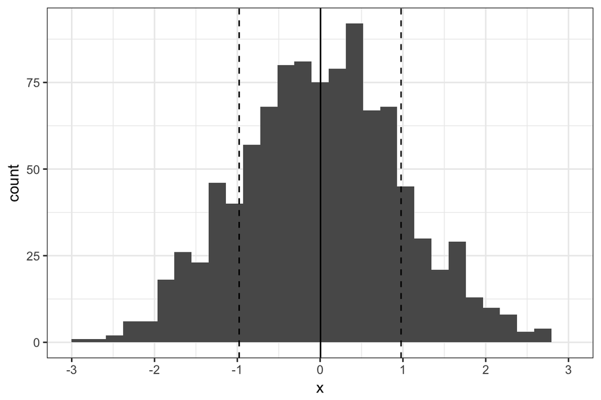

## Approximation

Law of big numbers

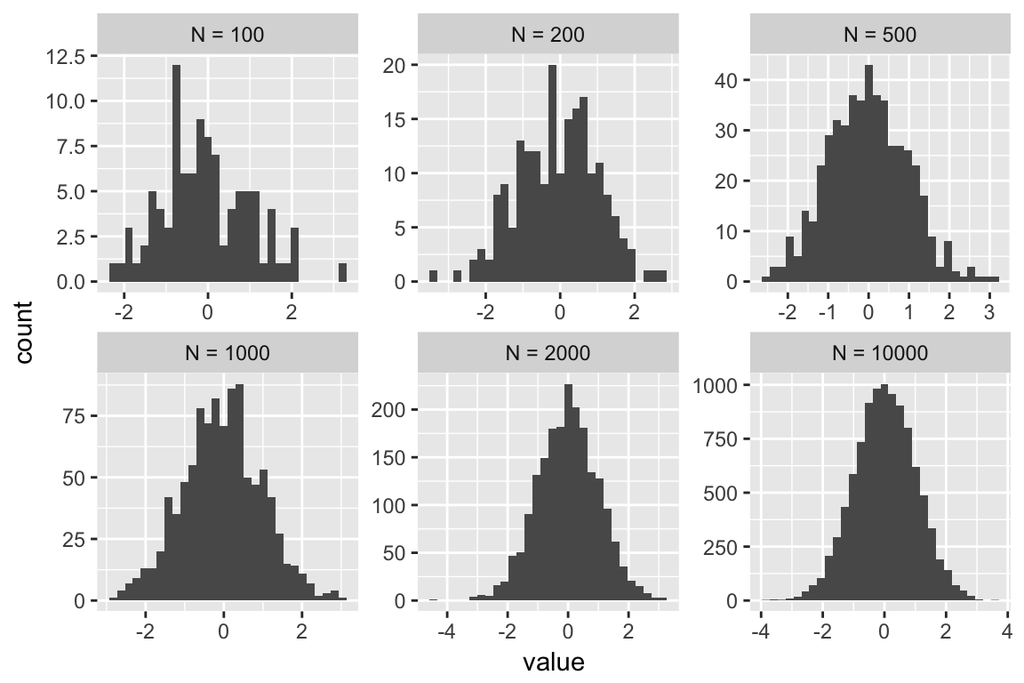

```r
obs <- c(100,200,500,1000,2000,10000)
sim_data <- data.frame()
for(i in seq_along(obs)){
  value <- rnorm(obs[i], mean = 0, sd = 1)
  sample  <- rep(obs[i], obs[i])
  sim_data <- rbind(sim_data, cbind(sample, value))
}

sim_data$sample1 <- paste0("N = ", sim_data$sample)

sim_data %>%
  ggplot(aes(value)) +
  geom_histogram() +
  facet_wrap( ~ reorder(sample1, sample),
              nrow = 2, scales = "free")
```

ggplot2 is a part of the tidyverse, an ecosystem of packages designed with common APIs and a shared philosophy. Learn more at tidyverse.org.

[^1]: There is proffesional support, but…↩
[^2]: A footnote here.↩